# Лабораторная работа №7

Расширенные настройки межсетевого экрана

Гашимова Эсма Эльшан кызы

1132247520@rudn.ru

Российский университет дружбы народов

2026-10-06

# Цели и задачи работы

## Цель лабораторной работы

Настроить межсетевой экран виртуальной машины `server` для доступа к SSH через порт `2022`.

Также необходимо настроить перенаправление портов, включить маскарадинг для доступа клиента к сети Интернет и сохранить выполненные настройки в проекте Vagrant.

# Процесс выполнения лабораторной работы

## Создание пользовательской службы FirewallD

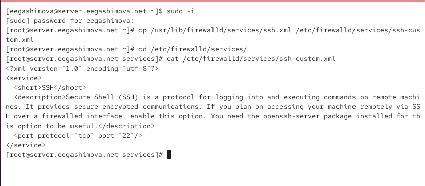

Создание пользовательского файла службы SSH и просмотр его содержимого

## Редактирование службы ssh-custom

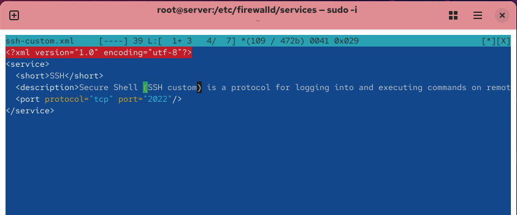

Редактирование пользовательской службы ssh-custom

## Просмотр доступных служб FirewallD

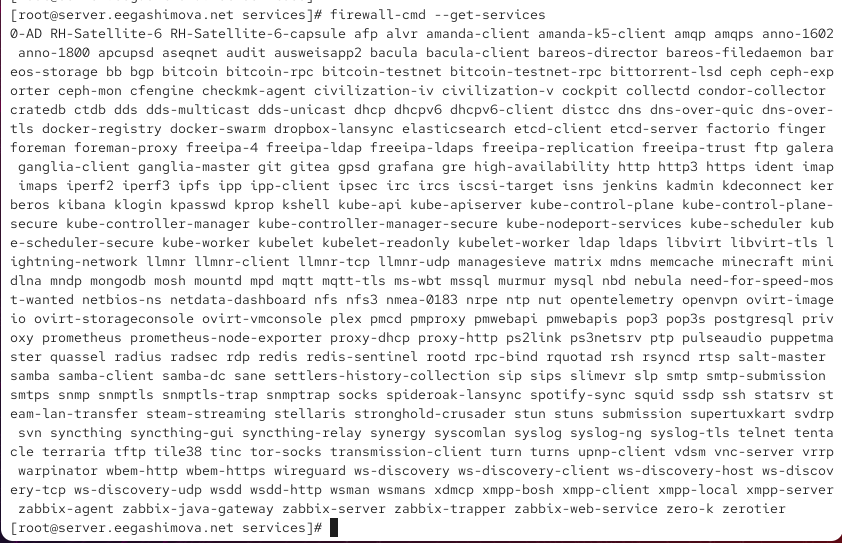

Список служб FirewallD до перезагрузки конфигурации

## Перезагрузка конфигурации FirewallD

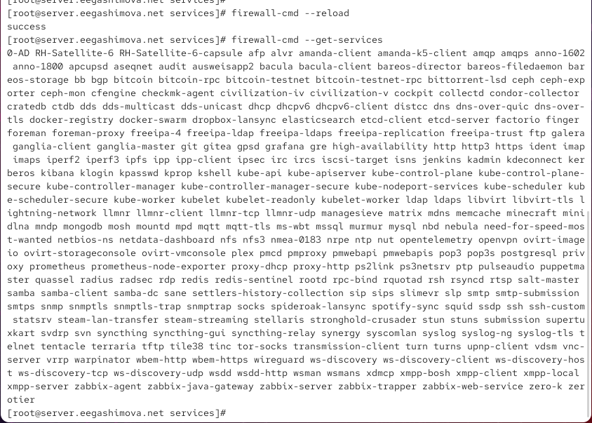

Появление службы ssh-custom после перезагрузки FirewallD

## Активация службы ssh-custom

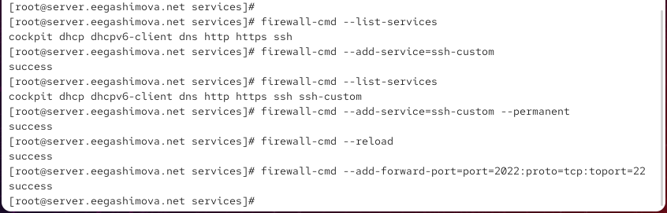

Добавление службы ssh-custom в активную и постоянную конфигурацию FirewallD

## Проверка SSH через порт 2022

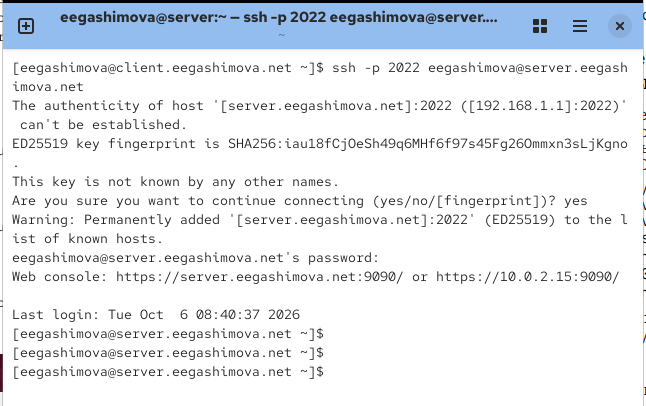

Проверка SSH-подключения к серверу через порт 2022

## Настройка IPv4 Forwarding и Masquerading

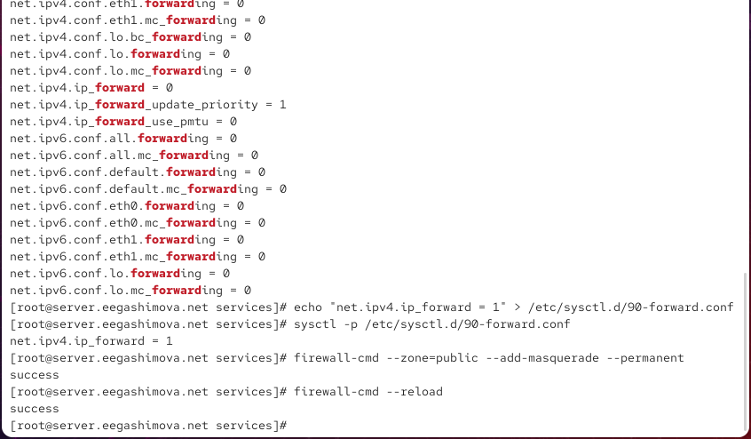

Включение IPv4 Forwarding и маскарадинга на сервере

## Проверка доступа клиента к Интернету

[figure not shown]

Проверка доступа клиента к сети Интернет

## Подготовка конфигурации для Vagrant

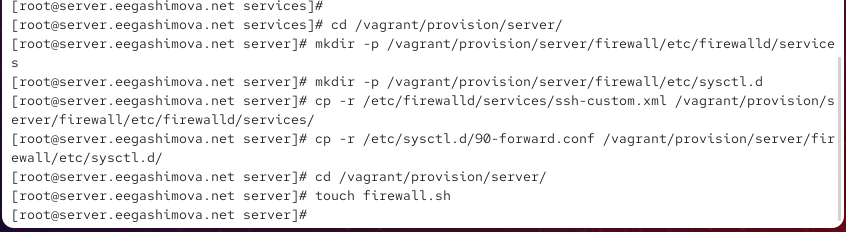

Подготовка каталогов и файлов для автоматической настройки FirewallD

## Создание скрипта firewall.sh

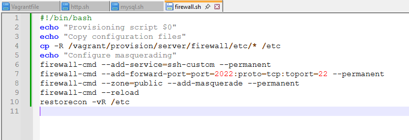

Скрипт firewall.sh для автоматической настройки межсетевого экрана

# Результаты работы

## Пользовательская служба FirewallD

На сервере был создан файл пользовательской службы:

```
/etc/firewalld/services/ssh-custom.xml
```

## Перенаправление порта SSH

На сервере было настроено перенаправление порта `2022` на стандартный порт SSH `22`:

```
firewall-cmd --add-forward-port=port=2022:proto=tcp:toport=22
```

## Настройка IPv4 Forwarding

Для включения маршрутизации IPv4-пакетов был создан файл: /etc/sysctl.d/90-forward.conf

В файл была добавлена строка: net.ipv4.ip_forward = 1

## Настройка маскарадинга

Для организации доступа клиента к сети Интернет через сервер был включён маскарадинг в зоне `public`:

```
firewall-cmd --zone=public --add-masquerade --permanent
firewall-cmd --reload
```

После этого на клиентской машине была выполнена проверка доступа к Интернету.

## Вывод

В ходе лабораторной работы была выполнена расширенная настройка межсетевого экрана `firewalld`.

Была создана пользовательская служба `ssh-custom`, настроен доступ к SSH через порт `2022`, выполнено перенаправление портов и включён маскарадинг.

Также была проверена возможность выхода клиентской виртуальной машины в Интернет через сервер.

В завершение настройки были сохранены в проекте Vagrant, что позволяет автоматически воспроизводить конфигурацию межсетевого экрана при повторном развёртывании виртуальной машины.